# Prosper Loan Data Exploration

## by Ahmed Khaled Mohamed Salah Abdelrahman

## Preliminary Wrangling

This dataset is a financial dataset and this is related to the loan, borrowers, lenders, interest rates and stuffs like that. Prosper or Prosper Marketplace Inc. is a San Francisco, California based company specializing in loans at low interest rates to the borrowers. In this dataset, we are using the data from the Posper to analyse it and trying to find the pattern in the Prosper data. [[*]](https://rstudio-pubs-static.s3.amazonaws.com/284488_195ef48d299e46f5b009987c8b988b69.html)

*The dataset is one of Udacity datasets for this project...*

```python
# import all packages and set plots to be embedded inline
import numpy as np
import pandas as pd
import matplotlib.pyplot as plt
import seaborn as sb

%matplotlib inline
```

```python
loans_dataset = pd.read_csv("prosperLoanData.csv")
loans_dataset.head()
```

|  | ListingKey | ListingNumber | ListingCreationDate | CreditGrade | Term | LoanStatus | ClosedDate | BorrowerAPR | BorrowerRate | LenderYield | ... | LP_ServiceFees | LP_CollectionFees | LP_GrossPrincipalLoss | LP_NetPrincipalLoss | LP_NonPrincipalRecoverypayments | PercentFunded | Recommendations | InvestmentFromFriendsCount | InvestmentFromFriendsAmount | Investors |
| --- | --- | --- | --- | --- | --- | --- | --- | --- | --- | --- | --- | --- | --- | --- | --- | --- | --- | --- | --- | --- | --- |
| 0 | 1021339766868145413AB3B | 193129 | 2007-08-26 19:09:29.263000000 | C | 36 | Completed | 2009-08-14 00:00:00 | 0.16516 | 0.1580 | 0.1380 | ... | -133.18 | 0.0 | 0.0 | 0.0 | 0.0 | 1.0 | 0 | 0 | 0.0 | 258 |
| 1 | 10273602499503308B223C1 | 1209647 | 2014-02-27 08:28:07.900000000 | NaN | 36 | Current | NaN | 0.12016 | 0.0920 | 0.0820 | ... | 0.00 | 0.0 | 0.0 | 0.0 | 0.0 | 1.0 | 0 | 0 | 0.0 | 1 |
| 2 | 0EE9337825851032864889A | 81716 | 2007-01-05 15:00:47.090000000 | HR | 36 | Completed | 2009-12-17 00:00:00 | 0.28269 | 0.2750 | 0.2400 | ... | -24.20 | 0.0 | 0.0 | 0.0 | 0.0 | 1.0 | 0 | 0 | 0.0 | 41 |
| 3 | 0EF5356002482715299901A | 658116 | 2012-10-22 11:02:35.010000000 | NaN | 36 | Current | NaN | 0.12528 | 0.0974 | 0.0874 | ... | -108.01 | 0.0 | 0.0 | 0.0 | 0.0 | 1.0 | 0 | 0 | 0.0 | 158 |
| 4 | 0F023589499656230C5E3E2 | 909464 | 2013-09-14 18:38:39.097000000 | NaN | 36 | Current | NaN | 0.24614 | 0.2085 | 0.1985 | ... | -60.27 | 0.0 | 0.0 | 0.0 | 0.0 | 1.0 | 0 | 0 | 0.0 | 20 |

5 rows × 81 columns

```python
loans_dataset.info()
```

```
<class 'pandas.core.frame.DataFrame'>
RangeIndex: 113937 entries, 0 to 113936
Data columns (total 81 columns):
 #   Column                               Non-Null Count   Dtype
---  ------                               --------------   -----
 0   ListingKey                           113937 non-null  object
 1   ListingNumber                        113937 non-null  int64
 2   ListingCreationDate                  113937 non-null  object
 3   CreditGrade                          28953 non-null   object
 4   Term                                 113937 non-null  int64
 5   LoanStatus                           113937 non-null  object
 6   ClosedDate                           55089 non-null   object
 7   BorrowerAPR                          113912 non-null  float64
 8   BorrowerRate                         113937 non-null  float64
 9   LenderYield                          113937 non-null  float64
```

[output cut: 73 more lines]

```python
# Formatting the name of some features to be compatible to use later...
loans_dataset = loans_dataset.rename(columns = {
    'ProsperRating (numeric)' : 'ProsperRating_numeric',
    'ProsperRating (Alpha)': 'ProsperRating_alpha',
    'ListingCategory (numeric)': 'ListingCategory_numeric',
    'TradesNeverDelinquent (percentage)': 'TradesNeverDelinquent_percentage'
})
```

```python
loans_dataset.info()
```

```
<class 'pandas.core.frame.DataFrame'>
RangeIndex: 113937 entries, 0 to 113936
Data columns (total 81 columns):
 #   Column                               Non-Null Count   Dtype
---  ------                               --------------   -----
 0   ListingKey                           113937 non-null  object
 1   ListingNumber                        113937 non-null  int64
 2   ListingCreationDate                  113937 non-null  object
 3   CreditGrade                          28953 non-null   object
 4   Term                                 113937 non-null  int64
 5   LoanStatus                           113937 non-null  object
 6   ClosedDate                           55089 non-null   object
 7   BorrowerAPR                          113912 non-null  float64
 8   BorrowerRate                         113937 non-null  float64
 9   LenderYield                          113937 non-null  float64
```

[output cut: 73 more lines]

### What is the structure of your dataset?

> The data set consists of 113937 rows (records) with 81 columns (features).

### What is/are the main feature(s) of interest in your dataset?

> We will focus our interset in some features:
1. BorroweState
2. LoanStatus
3. LenderYield
4. Occupation
5. EmploymentStatus
6. EmploymentStatusDuration
7. CurrentlyInGroup
8. IncomeRange
9. StatedMonthlyIncome
10. Investors
11. ProsperRating_numeric
12. LoanOriginalAmount
13. BorrowerRate

Our target will be the `BorrowerRate` to predict the interest that returns to the borrower. Also, we may be interested in `LoanOriginalAmount` to find relations between the amount of loan with other features.

```python
# Show the number of unique values for each feature to show which are
# categorial and which are quantitative
features = list('BorrowerState LoanStatus LenderYield Occupation EmploymentStatus EmploymentStatusDuration CurrentlyInGroup IncomeRange StatedMonthlyIncome Investors ProsperRating_numeric LoanOriginalAmount BorrowerRate'.split())
for ft in features:
    number_of_values = len(loans_dataset[ft].unique())
    print("{}: {}".format(ft, number_of_values))
```

```
BorrowerState: 52
LoanStatus: 12
LenderYield: 2283
Occupation: 68
EmploymentStatus: 9
EmploymentStatusDuration: 606
CurrentlyInGroup: 2
IncomeRange: 8
StatedMonthlyIncome: 13502
Investors: 751
ProsperRating_numeric: 8
LoanOriginalAmount: 2468
BorrowerRate: 2294
```

```python
categorial_features = list('BorrowerState LoanStatus EmploymentStatus CurrentlyInGroup IncomeRange ProsperRating_numeric'.split())
for cat in categorial_features:
    labels = loans_dataset[cat].unique()
    print("{}: {}".format(cat, labels))
```

```
BorrowerState: ['CO' 'GA' 'MN' 'NM' 'KS' 'CA' 'IL' 'MD' nan 'AL' 'AZ' 'VA' 'FL' 'PA' 'OR'
 'MI' 'NY' 'LA' 'WI' 'OH' 'NC' 'WA' 'NV' 'NJ' 'TX' 'AR' 'SC' 'DE' 'MO'
 'NE' 'UT' 'DC' 'MA' 'CT' 'IN' 'KY' 'OK' 'MS' 'WV' 'RI' 'TN' 'ID' 'MT'
 'HI' 'NH' 'VT' 'WY' 'ME' 'AK' 'IA' 'SD' 'ND']
LoanStatus: ['Completed' 'Current' 'Past Due (1-15 days)' 'Defaulted' 'Chargedoff'
 'Past Due (16-30 days)' 'Cancelled' 'Past Due (61-90 days)'
 'Past Due (31-60 days)' 'Past Due (91-120 days)' 'FinalPaymentInProgress'
 'Past Due (>120 days)']
EmploymentStatus: ['Self-employed' 'Employed' 'Not available' 'Full-time' 'Other' nan
 'Not employed' 'Part-time' 'Retired']
CurrentlyInGroup: [ True False]
IncomeRange: ['$25,000-49,999' '$50,000-74,999' 'Not displayed' '$100,000+'
 '$75,000-99,999' '$1-24,999' 'Not employed' '$0']
ProsperRating_numeric: [nan  6.  3.  5.  2.  4.  7.  1.]
```

```python
# Formatting IncomeRange for better dealing later...
loans_dataset['IncomeRange'] = loans_dataset['IncomeRange'].map({
    '$0': '0',
    '$1-24,999': '1-25K',
    '$25,000-49,999': '25K-50K',
    '$50,000-74,999': '50K-75K',
    '$75,000-99,999': '75K-100K',
    '$100,000+': '100K+',
    'Not displayed': 'Not displayed',
    'Not employed': 'Not employed'
})
```

```python
# Specify order for each ordinal categorial variables
categorial_features_ordered = {
    'LoanStatus': list('Current,FinalPaymentInProgress,Completed,Chargedoff,Cancelled,Defaulted,Past Due (1-15 days),Past Due (16-30 days),Past Due (31-60 days),Past Due (61-90 days),Past Due (91-120 days),Past Due (>120 days)'.split(',')),
    'EmploymentStatus': list('Self-employed,Employed,Full-time,Part-time,Not employed,Not available,Other,Retired'.split(',')),
    'IncomeRange': list('Not employed|0|1-25K|25K-50K|50K-75K|100K+|Not displayed'.split('|')),
    'ProsperRating_numeric': list(range(1, 8))
}
```

```python
loans_dataset = loans_dataset[features]
```

```python
for ord_cat in categorial_features_ordered.keys():
    order = pd.api.types.CategoricalDtype(ordered=True, categories = categorial_features_ordered[ord_cat])
    loans_dataset[ord_cat] = loans_dataset[ord_cat].astype(order)
```

```python
loans_dataset.dropna(inplace=True)
```

```python
loans_dataset.reset_index(inplace=True)
loans_dataset.drop(columns = 'index', axis = 1, inplace=True)
```

```python
loans_dataset.info()
```

```
<class 'pandas.core.frame.DataFrame'>
RangeIndex: 69106 entries, 0 to 69105
Data columns (total 13 columns):
 #   Column                    Non-Null Count  Dtype
---  ------                    --------------  -----
 0   BorrowerState             69106 non-null  object
 1   LoanStatus                69106 non-null  category
 2   LenderYield               69106 non-null  float64
 3   Occupation                69106 non-null  object
 4   EmploymentStatus          69106 non-null  category
 5   EmploymentStatusDuration  69106 non-null  float64
 6   CurrentlyInGroup          69106 non-null  bool
 7   IncomeRange               69106 non-null  category
 8   StatedMonthlyIncome       69106 non-null  float64
 9   Investors                 69106 non-null  int64
 10  ProsperRating_numeric     69106 non-null  category
 11  LoanOriginalAmount        69106 non-null  int64
 12  BorrowerRate              69106 non-null  float64
dtypes: bool(1), category(4), float64(4), int64(2), object(2)
memory usage: 4.5+ MB
```

## Our new data set after filtering the missing values and only focusing on some features, we reduced our size to 69 thousand records with 13 features. Any statistics will be stated on the new dataset

## Univariate Exploration

### BorrowerState

The states of the borrowes

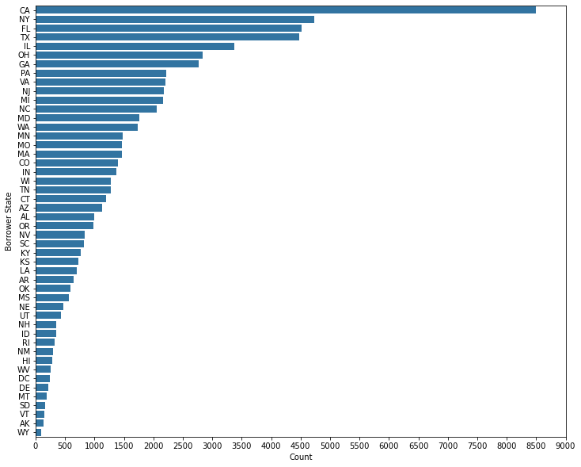

```python
plt.figure(figsize=[12, 10])
blue_color = sb.color_palette()[0]
sb.countplot(data = loans_dataset,
            y = 'BorrowerState',
            order = loans_dataset.BorrowerState.value_counts().index,
            color = blue_color)
plt.ylabel('Borrower State')
counts = np.arange(0, 9500, 500)
counts_labels = ['{}'.format(count) for count in counts]
plt.xlabel('Count')
plt.xticks(counts, counts_labels);
```

**It's obvious that most of the compaines borrowers live or come from California with about 8600. New York, Texas, and Florida come next with more than 4500 borrower for each. Wyoming is the least.**

### LoanStatus

The cuurent status of the loan

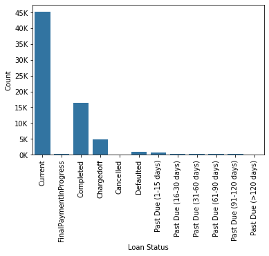

```python
sb.countplot(data = loans_dataset,
            x = 'LoanStatus',
            color = blue_color)
plt.xticks(rotation = 90)
plt.xlabel('Loan Status')
plt.ylabel('Count');
plt.yticks(np.arange(0, 50000, 5000), '0K 5K 10K 15K 20K 25K 30K 35K 40K 45K'.split());
```

### LenderYield

The lender's interest rate

```python
loans_dataset.LenderYield.describe()
```

```
count    69106.000000
mean         0.188941
std          0.075015
min          0.030000
25%          0.129600
50%          0.180500
75%          0.249900
max          0.340000
Name: LenderYield, dtype: float64
```

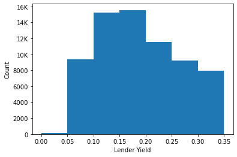

```python
lender_yield_bins = np.arange(0, 0.35 + 0.05, 0.05)
plt.hist(
    data = loans_dataset,
    x = 'LenderYield',
    bins = lender_yield_bins
);
plt.xlabel("Lender Yield")
plt.ylabel("Count");
plt.yticks(np.arange(0, 18000, 2000), '0 2000 4000 6000 8000 10K 12K 14K 16K'.split());
```

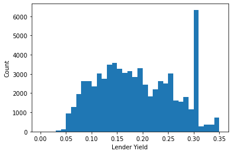

```python
lender_yield_bins_2 = np.arange(0, 0.35 + 0.01, 0.01)
plt.hist(
    data = loans_dataset,
    x = 'LenderYield',
    bins = lender_yield_bins_2
);
plt.xlabel("Lender Yield")
plt.ylabel("Count");
```

From the two visualizations above, the majority of the lenders, 30 thousand (43%), have an yield (interest) in the range of 10%-20%. Looking in more detail, we can observe that around 6000 lenders (8.5%) use exactly 30%, it is the most common percentage among all lenders. Not too many use a percentage higher than 30% or less than 10%.

### Occupation

Occupation of borrower at the time of listing.

[figure not shown]

```python
sb.countplot(
    data = loans_dataset,
    y = 'Occupation',
    color = blue_color,
    order = loans_dataset.Occupation.value_counts().index
)
```

As they are too many occupations, we will only look at the most common ones...

```python
occupation_count = loans_dataset.Occupation.value_counts()[1:26] # 1 to remove Other...
```

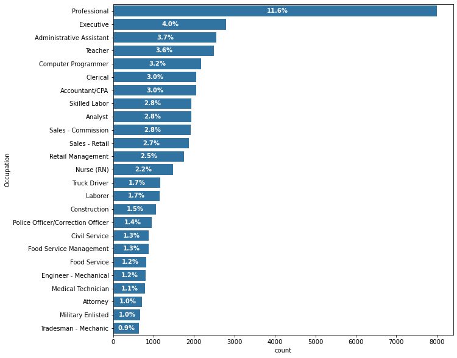

```python
occupation_filtered = loans_dataset[loans_dataset.Occupation.isin(occupation_count.index)]
plt.figure(figsize=[10, 10])
sb.countplot(
    data = occupation_filtered,
    y = 'Occupation',
    color = blue_color,
    order = occupation_count.index
);

tot = loans_dataset.shape[0]

for i in range(len(occupation_count)):
    percentage = '{:.1f}%'.format(occupation_count[i] * 100 / tot)
    plt.text(occupation_count[i] / 2 - 200, i, percentage, va = 'center', color = 'w', weight = 'bold');
```

### EmploymentStatus

Current type of employment

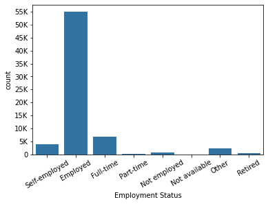

```python
sb.countplot(
    data = loans_dataset,
    x = 'EmploymentStatus',
    color = blue_color
)
plt.xticks(rotation = 30)
plt.yticks(np.arange(0, 60000, 5000), '0 5K 10K 15K 20K 25K 30K 35K 40K 45K 50K 55K'.split());
plt.xlabel("Employment Status")
```

### EmploymentStatusDuration

How long the employee has been employed in months

```python
loans_dataset.EmploymentStatusDuration.describe()
```

```
count    69106.000000
mean       100.582670
std         94.806167
min          0.000000
25%         30.000000
50%         72.000000
75%        144.000000
max        755.000000
Name: EmploymentStatusDuration, dtype: float64
```

We may prefer to present the EmploymentStatusDuration in years instead of months.

```python
loans_dataset['EmploymentStatusDuration_years'] = loans_dataset['EmploymentStatusDuration'] / 12
```

```python
loans_dataset['EmploymentStatusDuration_years'].describe()
```

```
count    69106.000000
mean         8.381889
std          7.900514
min          0.000000
25%          2.500000
50%          6.000000
75%         12.000000
max         62.916667
Name: EmploymentStatusDuration_years, dtype: float64
```

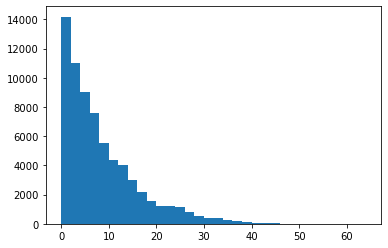

```python
years_bins = np.arange(0, 63 + 2, 2)
plt.hist(
    data = loans_dataset,
    x = 'EmploymentStatusDuration_years',
    bins = years_bins
);
```

A log transform will be very helpful, as this distribuition is clearly right-skewed and has a long descending tail.

```python
# Avoid division by zero encountring in log10
loans_dataset.loc[loans_dataset[loans_dataset['EmploymentStatusDuration_years'] == 0.001].index, ['EmploymentStatusDuration_years']] = 10 ** -5
```

```python
np.log10(loans_dataset.EmploymentStatusDuration_years).describe()
```

[output not shown]

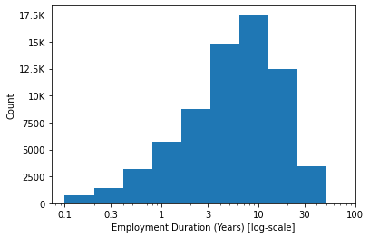

```python
log_years_bins = 10 ** np.arange(-1, 2, 0.3)
plt.hist(
    data = loans_dataset,
    x = 'EmploymentStatusDuration_years',
    bins = log_years_bins,
);
plt.xscale('log');
x_pos = [0.1, 0.3, 1, 3, 10, 30, 100]
x_labels = ['{}'.format(x) for x in x_pos]
plt.xticks(x_pos, x_labels);
plt.xlabel("Employment Duration (Years) [log-scale]")
plt.ylabel("Count");
plt.yticks(np.arange(0, 20000, 2500), '0 2500 5000 7500 10K 12.5K 15K 17.5K'.split());
```

### CurrentlyInGroup

If the borrower was in a group at the time of listing.

```python
group_values = loans_dataset.CurrentlyInGroup.value_counts()
group_values
```

```
False    67270
True      1836
Name: CurrentlyInGroup, dtype: int64
```

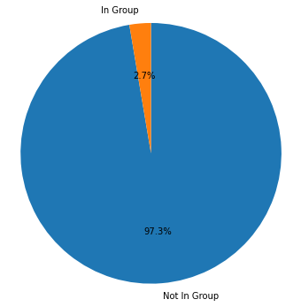

```python
plt.figure(figsize = [6, 6])
group_values = loans_dataset.CurrentlyInGroup.value_counts()
total = loans_dataset.shape[0]

def calc_pct(pct):
    return '{:.1f}%'.format(pct)

group_labels = ['Not In Group', 'In Group']
plt.pie(x = group_values, labels = group_labels, startangle = 90, counterclock = False, autopct = lambda pct: calc_pct(pct));
plt.axis("square");
```

97.3% of the borrowers are working individually, 2.7% are working in groups.

### IncomeRange

The income range of the borrower at the time the listing was created.

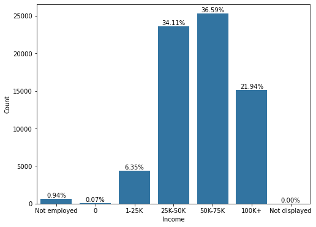

```python
plt.figure(figsize = [8, 6])
sb.countplot(
    data = loans_dataset,
    x = 'IncomeRange',
    color = blue_color
);
plt.xlabel("Income")
plt.ylabel("Count");

income_counts = loans_dataset.IncomeRange.value_counts()

income_labels = 'Not employed|0|1-25K|25K-50K|50K-75K|100K+|Not displayed'.split('|')

for i in range(len(income_counts)):
    cat = income_labels[i]
    count = income_counts[cat]
    percentage = '{:.2f}%'.format(count / total * 100)
    plt.text(i, count + 200, percentage, ha = 'center');
```

37% of borrowers has income in the range of 50K-75K, 34% in the range of 25K-50K and 22% gains income of 100K and more.

### StatedMonthlyIncome

The monthly income the borrower stated at the time the listing was created.

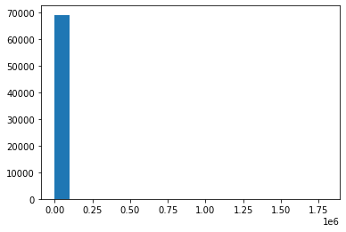

```python
monthly_income_bins = np.arange(loans_dataset.StatedMonthlyIncome.min(), loans_dataset.StatedMonthlyIncome.max() + 100000, 100000)
plt.hist(
    data = loans_dataset,
    x = 'StatedMonthlyIncome',
    bins = monthly_income_bins
);
```

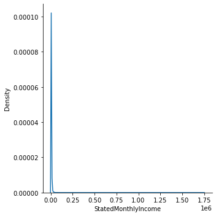

```python
sb.displot(
    data = loans_dataset,
    x = 'StatedMonthlyIncome',
    kind='kde'
);
```

There is outliers in StatedMonthlyIncome, let's focus our scope into smaller range...

```
(0.0, 20000.0)
```

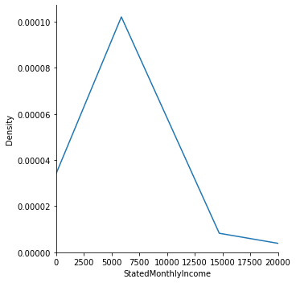

```python
sb.displot(
    data = loans_dataset,
    x = 'StatedMonthlyIncome',
    kind='kde'
);
plt.xlim([0, 20000])
```

The majority of Monthly income is in the range (0, 20000)!

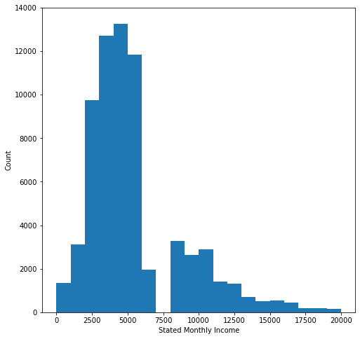

```python
monthly_filtered  = loans_dataset.query('StatedMonthlyIncome <= 20000')
monthly_income_bins = np.arange(monthly_filtered.StatedMonthlyIncome.min(), monthly_filtered.StatedMonthlyIncome.max() + 1000, 1000)
plt.figure(figsize = [8, 8])
plt.hist(
    data = monthly_filtered,
    x = 'StatedMonthlyIncome',
    bins = monthly_income_bins
);
plt.xlabel("Stated Monthly Income")
plt.ylabel("Count");
plt.yticks(np.arange(0, 15000, 2000));
```

### Investors

The number of investors that funded the loan.

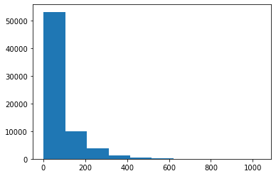

```python
plt.hist(
    data = loans_dataset,
    x = 'Investors'
);
```

Our limits in the Investors are 600, we also may need to use log scale here...

```python
np.log10(600)
```

```
2.7781512503836434
```

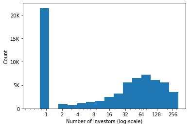

```python
investors_bins = 10 ** np.arange(np.log10(0.5), np.log10(400), np.log10(1.5))
plt.hist(
    data = loans_dataset,
    x = 'Investors',
    bins = investors_bins
);
x_pos = [1, 2, 4, 8, 16, 32, 64, 128, 256]
x_labels = ['{}'.format(x) for x in x_pos]
plt.xscale('log')
plt.xticks(x_pos, x_labels);
plt.xlabel("Number of Investors (log-scale)")
plt.ylabel("Count")
plt.yticks([0, 5000, 10000, 15000, 20000], '0 5K 10K 15K 20K'.split());
```

### ProsperRating_numeric

The Prosper Rating assigned at the time the listing was created: 0 - N/A, 1 - HR, 2 - E, 3 - D, 4 - C, 5 - B, 6 - A, 7 - AA. Applicable for loans originated after July 2009.

```python
loans_dataset.ProsperRating_numeric.value_counts()
```

```
4    14833
5    12395
3    11987
6    11432
2     8301
1     6057
7     4101
Name: ProsperRating_numeric, dtype: int64
```

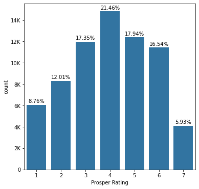

```python
plt.figure(figsize = [6, 6])

sb.countplot(
    data = loans_dataset,
    x = 'ProsperRating_numeric',
    color = blue_color
);

plt.xlabel("Prosper Rating");

rating_counts = [6057, 8301, 11987, 14833, 12395, 11432, 4101]

rating_labels = list(range(1, 8))

for i in range(len(rating_counts)):
    percentage = '{:.2f}%'.format(rating_counts[i] / total * 100)
    plt.text(i, rating_counts[i] + 200, percentage, ha = 'center')

plt.yticks(np.arange(0, 16000, 2000), '0 2K 4K 6K 8K 10K 12K 14K'.split());
```

The distribution of the prosper rating shows a uni-modal curve at the rating 4. on both sides the curve tends to decrease until it reaches a tail at rating 1 with 8.76% and rating 7 with 5.93%.

### LoanOriginalAmount

The origination amount of the loan.

```python
np.log10(loans_dataset['LoanOriginalAmount'].describe())
```

```
count    4.839516
mean     3.943106
std      3.791840
min      3.000000
25%      3.602060
50%      3.863323
75%      4.096910
max      4.544068
Name: LoanOriginalAmount, dtype: float64
```

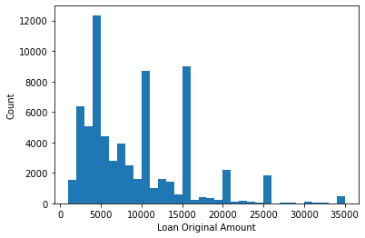

```python
amount_bins = np.arange(1000, 35000 + 1000, 1000)

plt.hist(
    data = loans_dataset,
    x = 'LoanOriginalAmount',
    bins = amount_bins
);

plt.xlabel("Loan Original Amount")
plt.ylabel("Count");
```

The distribution of the amounts of loans starts from 1000 increasing until it reaches it's first peak at 5000, 12000 borrowers were granted loan amount of 5000\$. The curve then decreases but suddenly has a sharp rise to 10000 \\$. Actually 8000 borrowers granted this amount as a loan. The curve decreases again and again a sudden rise to the amount of 15000 \$ which has 8000 borrowers. The same happens and we may find rises at 20000\\$ and 25000\$ with 1800 borrowers for each amount.

### BorrowerRate

The Borrower's interest rate for this loan.

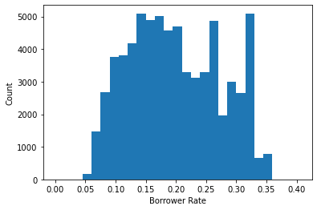

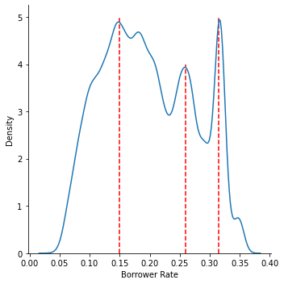

```python
borrwer_rate_bins = np.arange(0, 0.4 + 0.015, 0.015)

plt.hist(
    data = loans_dataset,
    x = 'BorrowerRate',
    bins = borrwer_rate_bins
)

plt.xlabel("Borrower Rate")
plt.ylabel("Count")

sb.displot(
    data = loans_dataset,
    x = 'BorrowerRate',
    kind = 'kde'
)
plt.xlabel("Borrower Rate");

plt.vlines(0.15, ymin=0, ymax=5, color = 'r', linestyles='--')
plt.vlines(0.26, ymin=0, ymax=4, color = 'r', linestyles='--')
plt.vlines(0.315, ymin=0, ymax=5, color = 'r', linestyles='--')
```

From the two above figures, we can detuct that there are 3 main rates of interest for the borrower; 15%, 26%, 31.5%. Nearly for each of the previous interest rates, about 5000 borrowers are recorded.

### Discuss the distribution(s) of your variable(s) of interest. Were there any unusual points? Did you need to perform any transformations?

> After each visualization, a comment(s) is added to illustrate the steps beside some comments in the code...

### Of the features you investigated, were there any unusual distributions? Did you perform any operations on the data to tidy, adjust, or change the form of the data? If so, why did you do this?

> Some modifications and comments are illustrated in the following table...

[output not shown]

## Bivariate Exploarion

We start with a general pair plot to plot the all bivaraite scatter plots between all features, we will select the ones we might find them interesting...

```python
sample = np.random.choice(a = loans_dataset.shape[0], size = 500, replace = False)

loans_sample = loans_dataset.loc[sample, :]
```

```python
numeric_variables = ['LenderYield', 'EmploymentStatusDuration_years', 'StatedMonthlyIncome', 'Investors', 'LoanOriginalAmount', 'BorrowerRate']
```

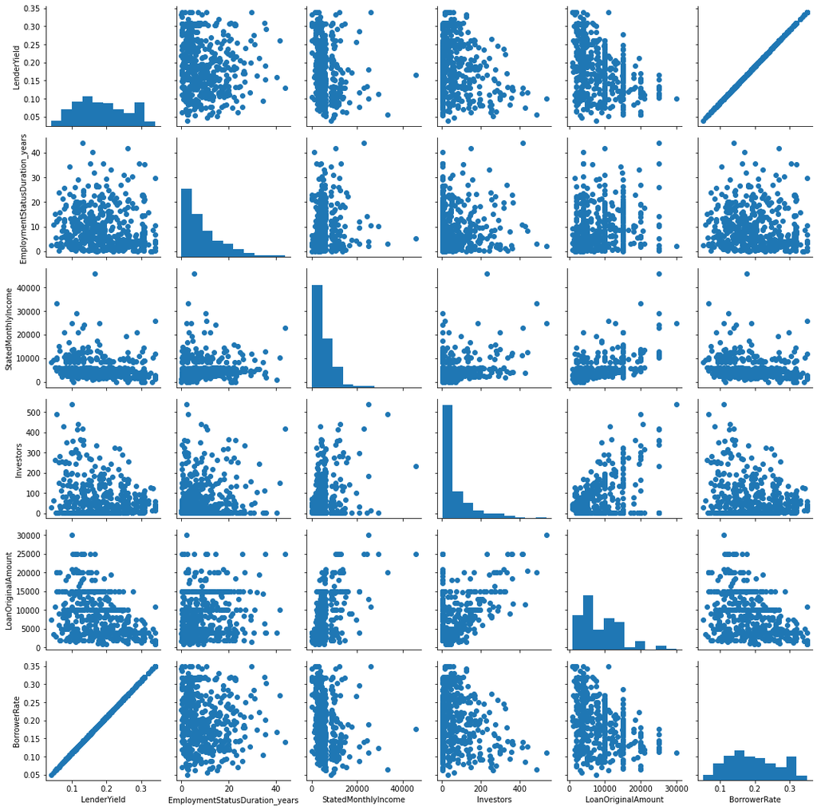

```python
g = sb.PairGrid(data = loans_sample, vars = numeric_variables)
g.map_diag(plt.hist)
g.map_offdiag(plt.scatter);
```

### Investors vs LoanOriginalAmount

First for simplicity, we will consider that the number of investors will start from 1 not 0, as the number of the borrowers with no investors is much higher that may cause conflict...

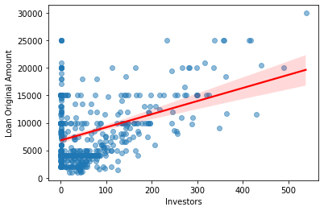

```python
sb.regplot(
    data = loans_sample.query("Investors != 0"),
    x = 'Investors',
    y = 'LoanOriginalAmount',
    fit_reg = True,
    x_jitter = 1,
    scatter_kws = {'alpha': 0.5},
    line_kws = {'color': 'r'}
);

plt.ylabel("Loan Original Amount");
```

There is a direct realtionship between the number of investors and the amount of the loan. A line with a positive slope can be fitted between the points.

### IncomeRange vs LoanOriginalAmount

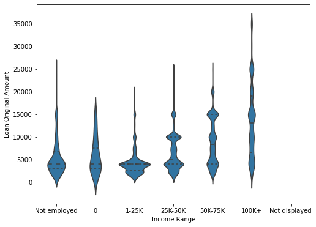

```python
plt.figure(figsize = [8, 6])
sb.violinplot(data = loans_dataset, x = 'IncomeRange', y = 'LoanOriginalAmount', color = sb.color_palette()[0], inner = 'quartile');
plt.xlabel("Income Range")
plt.ylabel("Loan Original Amount");
```

The borrowers with the 'Not employed' and the borrowers with income in the range of 1-25K share the same distribution in the amount of loan with a mean of qbout 4000\$. The range of amounts increase with the increase of the income. A borrower with an income in the range of 50K-75K \\$ are less likeable to have a loan amount greater than 15K\$. The distribution of the loan amount in the case of the income range (100K+) is quitely flat, the majority in this category are recieving loan of amount of just less than 15K\\$. Still, it is also likely if you are in this category to get more amounts than those in the (50K-75K).

A boxplot might show some details about the 5-number statisitic of the relationship...

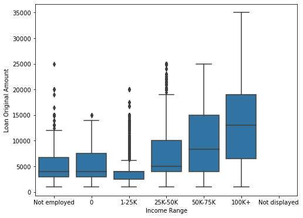

```python
plt.figure(figsize = [8, 6])
sb.boxplot(data = loans_dataset, x = 'IncomeRange', y = 'LoanOriginalAmount', color = sb.color_palette()[0]);
plt.xlabel("Income Range")
plt.ylabel("Loan Original Amount");
```

We deduct the same results, a direct realtionship between the income range and the amount of loan.

### ProsperRating_numeric vs LoanOriginalAmount

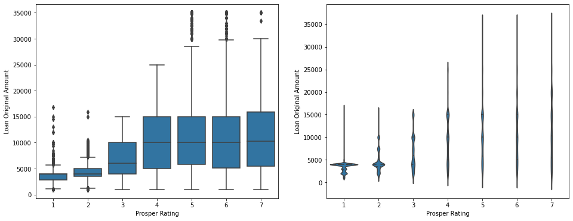

```python
plt.figure(figsize = (16, 6))

plt.subplot(1, 2, 1)
sb.boxplot(data = loans_dataset, x = 'ProsperRating_numeric', y = 'LoanOriginalAmount', color = sb.color_palette()[0]);
plt.xlabel("Prosper Rating")
plt.ylabel("Loan Original Amount")

plt.subplot(1, 2, 2)
sb.violinplot(data = loans_dataset, x = 'ProsperRating_numeric', y = 'LoanOriginalAmount', color = sb.color_palette()[0], inner = 'quartile');
plt.xlabel("Prosper Rating")
plt.ylabel("Loan Original Amount");
```

### Investors vs BorrowerRate

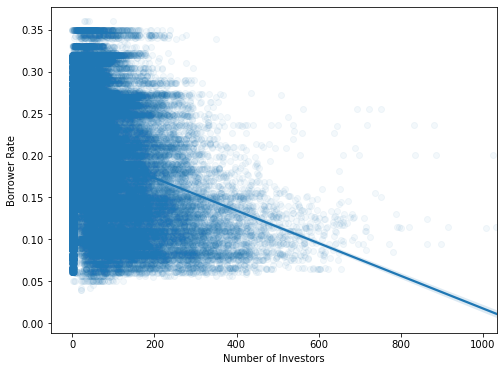

```python
plt.figure(figsize = (8, 6))
sb.regplot(
    data = loans_dataset.query('Investors > 0'),
    x = 'Investors',
    y = 'BorrowerRate',
    x_jitter = 2.5,
    scatter_kws = {'alpha': 0.05}
);
plt.xlabel("Number of Investors")
plt.ylabel("Borrower Rate");
```

An inverse realtioship is noticed between the number of investors and the borrower rate of interest. The majority of the borrowers who have 600 or more investors, their rate of interest doesn't surpass 15%.

### ProsperRating_numeric vs Investors

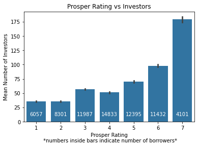

```python
sb.barplot(
    data = loans_dataset,
    x = 'ProsperRating_numeric',
    y = 'Investors',
    color = blue_color,
    ci = 95
)

for i in range(len(rating_counts)):
    count = rating_counts[i]
    plt.text(i, 10, count, ha = 'center', color = 'w')

plt.xlabel("Prosper Rating" + "\n *numbers inside bars indicate number of borrowers*");
plt.ylabel("Mean Number of Investors")
plt.title("Prosper Rating vs Investors");
```

As seen, with higher prosper rating, a higher number investors the borrower get. Few borrowers got a rating of 7, but they still manage to attract more investors.

### CurrentlyInGroup vs LoanOriginalAmount

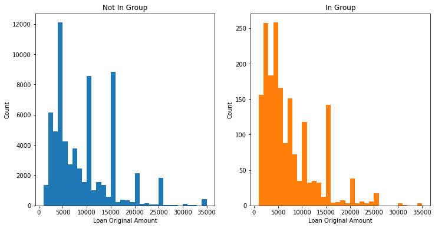

```python
plt.figure(figsize = [12, 6])
plt.subplot(1, 2, 1)
plt.hist(data = loans_dataset.query("CurrentlyInGroup == False"), x = 'LoanOriginalAmount', bins = amount_bins);
plt.title("Not In Group")
plt.xlabel("Loan Original Amount")
plt.ylabel("Count")
plt.subplot(1, 2, 2)
plt.hist(data = loans_dataset.query("CurrentlyInGroup == True"), x = 'LoanOriginalAmount', bins = amount_bins, color = sb.color_palette()[1]);
plt.title("In Group")
plt.xlabel("Loan Original Amount")
plt.ylabel("Count");
```

Being in a group doesn't have that big effect of getting more amount to your loan. The distribution in quite the same between both cases of working individually and working in a group.

### Talk about some of the relationships you observed in this part of the investigation. How did the feature(s) of interest vary with other features in the dataset?

### Did you observe any interesting relationships between the other features (not the main feature(s) of interest)?

| X | Y | Visualization | Comment |
| --- | --- | --- | --- |
| Investors | LoanOriginalAmount | Scatter | There is a direct realtionship between the number of investors and the amount of the loan. A line with a positive slope can be fitted between the points. |
| IncomeRange | LoanOriginalAmount | Violin / Box | The borrowers with the 'Not employed' and the borrowers with income in the range of 1-25K share the same distribution in the amount of loan with a mean of qbout 4000\$. The range of amounts increase w… |
| ProsperRating_numeric | LoanOriginalAmount | Violin / Box | We can deduce that the borrower with a Prosper rating of 4 or above is more likely to get a loan higher than 10K \$. The majority of the borrowers who have a rating of 4, 5, 6, 7 got loans with amount… |
| Investors | BorrowerRate | Scatter | An inverse realtioship is noticed between the number of investors and the borrower rate of interest. The majority of the borrowers who have 600 or more investors, their rate of interest doesn't surpas… |
| ProsperRating_numeric | Investors | Bar Plot | PAs seen, with higher prosper rating, a higher number investors the borrower get. Few borrowers got a rating of 7, but they still manage to attract more investors. |
| CurrentlyInGroup | LoanOriginalAmount | Histogram | Being in a group doesn't have that big effect of getting more amount to your loan. The distribution in quite the same between both cases of working individually and working in a group. |

## Multivariate Exploration

### ProsperRating_numeric vs Investors vs CurrentlyInGroup

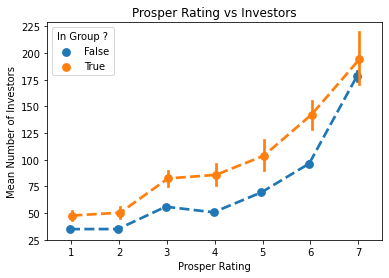

```python
sb.pointplot(
    data = loans_dataset,
    x = 'ProsperRating_numeric',
    y = 'Investors',
    hue = 'CurrentlyInGroup',
    dodge = True,
    linestyles = '--'
);
plt.xlabel("Prosper Rating")
plt.ylabel("Mean Number of Investors")
plt.title("Prosper Rating vs Investors");
plt.legend(title = "In Group ?")
```

Having a higher Prosper rating helps you attract more investors, but combining the grade with working in a group helps you even more. With high ratings, the number of investors increases with the acknowledge of being in a group more than individually.

### IncomeRange vs LoanOriginalAmount vs ProsperRating_numeric

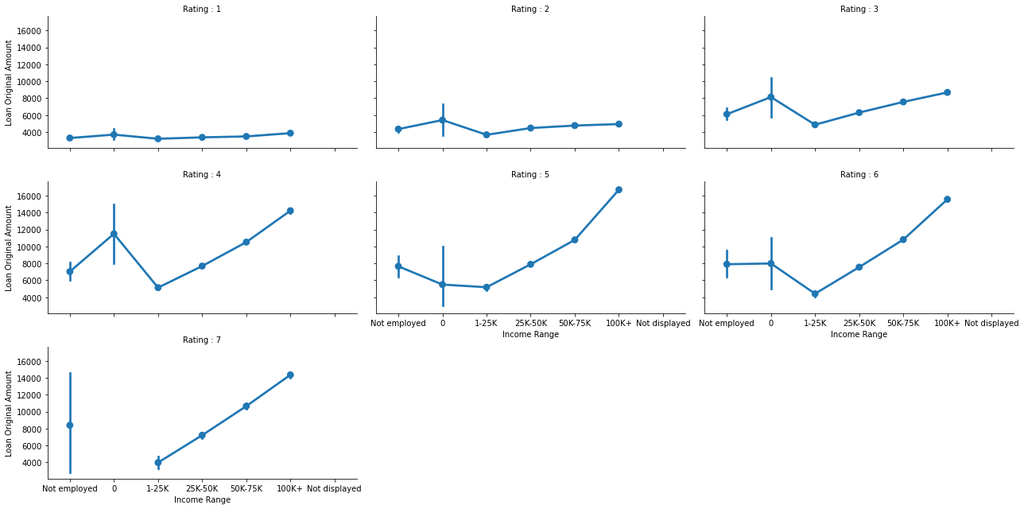

```python
g = sb.FacetGrid(
    data = loans_dataset,
    col = 'ProsperRating_numeric',
    col_wrap = 3,
    aspect = 2
)

g.map(sb.pointplot, "IncomeRange", "LoanOriginalAmount");

g.set_titles(col_template="Rating : {col_name}")
g.set_axis_labels("Income Range", "Loan Original Amount")
```

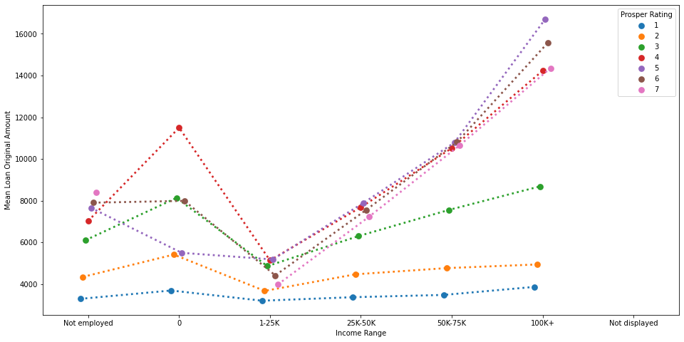

```python
plt.figure(figsize = [16, 8])
sb.pointplot(
    data = loans_dataset,
    x = 'IncomeRange',
    y = 'LoanOriginalAmount',
    hue = 'ProsperRating_numeric',
    linestyles = ':',
    ci = None,
    dodge = True
)
plt.legend(title = 'Prosper Rating')
plt.xlabel("Income Range")
plt.ylabel("Mean Loan Original Amount");
```

Considering taking each Prosper rating separately, we can deduce that the amount change of the loan is higher with the change in the income level in the ratings of 4, 5, 6, and 7. The ratings of 1, 2, and 3 don't show that high gradient.

Surprisingly, A rating of 7 showed a lower mean of loan amount that lower ratings 5, and 6.

### Talk about some of the relationships you observed in this part of the investigation. Were there features that strengthened each other in terms of looking at your feature(s) of interest?

### Were there any interesting or surprising interactions between features?

| X | Y | Hue | Visualization | Comments |
| --- | --- | --- | --- | --- |
| ProsperRating_numeric | Investors | CurrentlyInGroup | Point | Having a higher Prosper rating helps you attract more investors, but combining the grade with working in a group helps you even more. With high ratings, the number of investors increases with the ackn… |
| IncomeRange | LoanOriginalAmount | ProsperRating_numeric | Point | Considering taking each Prosper rating separately, we can deduce that the amount change of the loan is higher with the change in the income level in the ratings of 4, 5, 6, and 7. The ratings of 1, 2,… |